# Chapter 10: Dynamic regression models

maurogm 2023-08-22

- Link
- Regression with ARIMA errors using `fable`
- Forecasting
- Dymamic Harmonic regression
  - Example: Australian eating out expenditure

## Link

https://otexts.com/fpp3/dynamic.html

## Regression with ARIMA errors using `fable`

Queremos predecir la evolución del cambio en el consumo en función del cambio en el ingreso.

```
## Series: Consumption
## Model: LM w/ ARIMA(1,0,2) errors
##
## Coefficients:
##          ar1      ma1     ma2  Income  intercept
##       0.7070  -0.6172  0.2066  0.1976     0.5949
## s.e.  0.1068   0.1218  0.0741  0.0462     0.0850
##
## sigma^2 estimated as 0.3113:  log likelihood=-163.04
## AIC=338.07   AICc=338.51   BIC=357.8
```

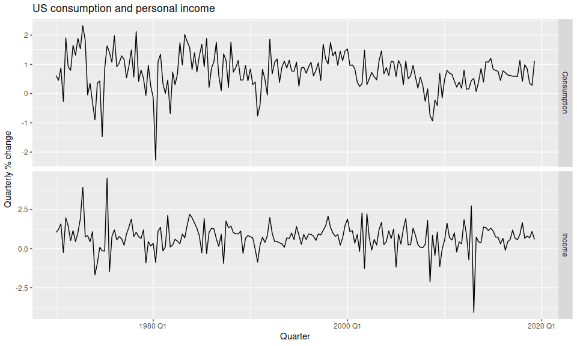

```r
us_change |>
  pivot_longer(c(Consumption, Income),
    names_to = "var", values_to = "value"
  ) |>
  ggplot(aes(x = Quarter, y = value)) +
  geom_line() +
  facet_grid(vars(var), scales = "free_y") +
  labs(
    title = "US consumption and personal income",
    y = "Quarterly % change"
  )

fit <- us_change |>
  model(ARIMA(Consumption ~ Income))
report(fit)
```

Usando la función `residuals` en el modelo ajustado, podemos obtener tanto los residuos de la regresión como los del modelo ARIMA (que deberían ser ruido blanco).

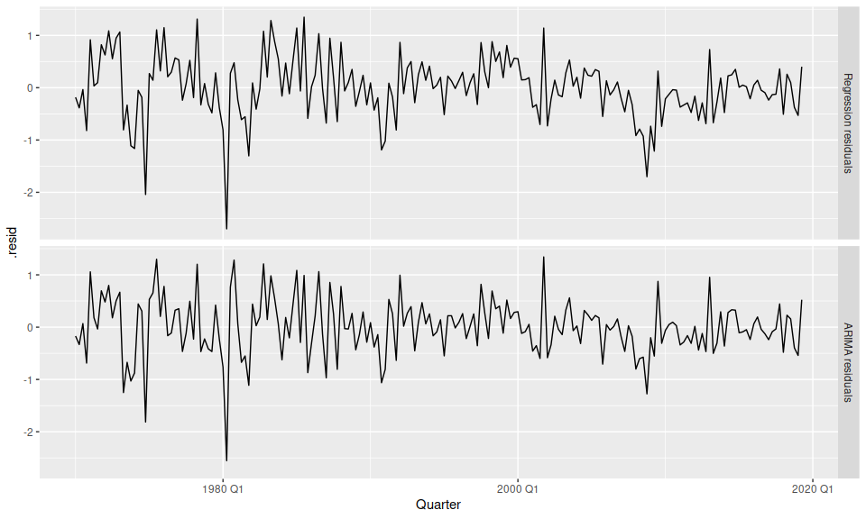

```r
bind_rows(
  `Regression residuals` =
    as_tibble(residuals(fit, type = "regression")),
  `ARIMA residuals` =
    as_tibble(residuals(fit, type = "innovation")),
  .id = "type"
) |>
  mutate(
    type = factor(type, levels = c(
      "Regression residuals", "ARIMA residuals"
    ))
  ) |>
  ggplot(aes(x = Quarter, y = .resid)) +
  geom_line() +
  facet_grid(vars(type))
```

Si no, `gg_tsresiduals` nos da directamente una visualización de los residuos finales (que son los del modelo ARIMA).

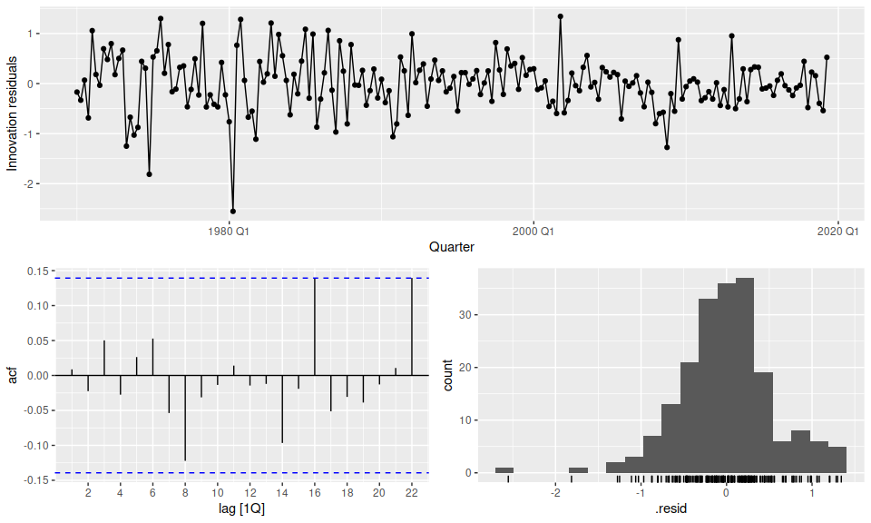

```r
fit |> gg_tsresiduals()
```

Pasando `type = "regression"` a `gg_tsresiduals` podemos ver el análisis de los residuos de la regresión. Muestran una clara autocorrelación, por lo que el modelo ARIMA para los errores fue claramente apropiado.

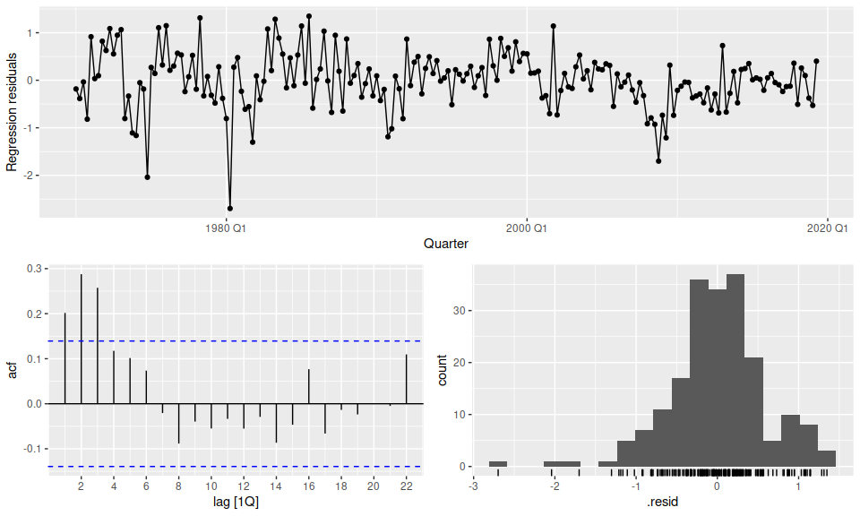

```r
fit |> gg_tsresiduals(type = "regression")
```

(La comparación no es justa, dado que habría que ver los residuos en un modelo lineal puro para determinar que el modelo ARIMA es apropiado). Si lo hacemos, vemos que efectivamente se llega a un modelo con residuos autocorrelacionados:

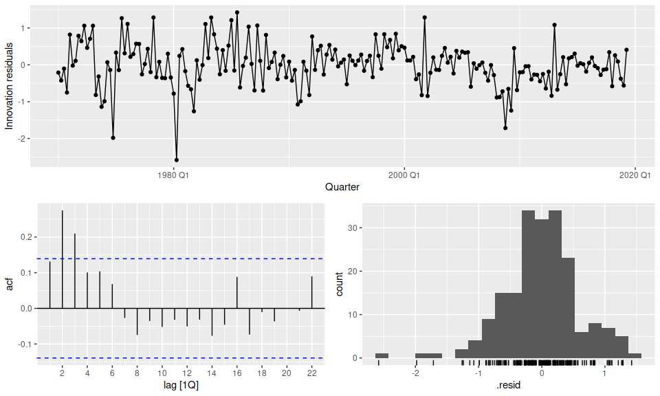

```r
us_change %>%
  model(TSLM(Consumption ~ Income)) %>%
  gg_tsresiduals()
```

## Forecasting

Ejemplificamos un proceso de forecasting con un modelo de regresión dinámica. Para ello, usamos los datos de demanda eléctrica de Victoria (Australia) y la temperatura máxima diaria como predictor.

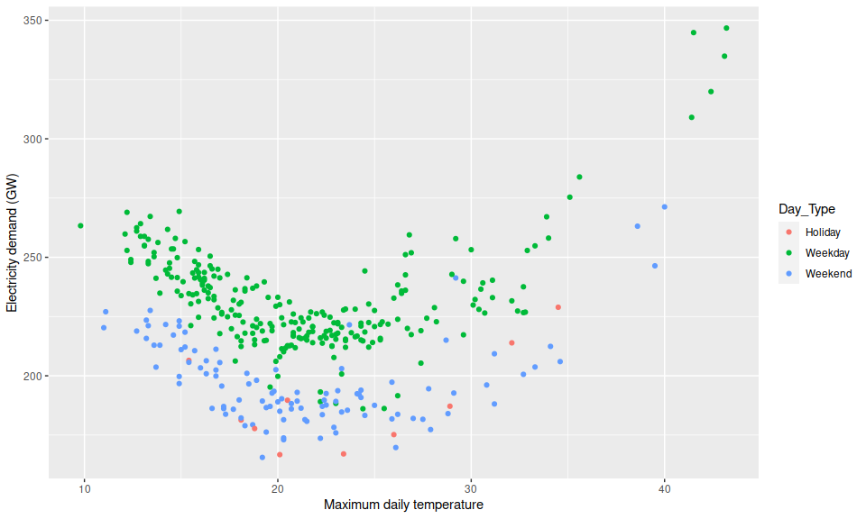

```r
vic_elec_daily <- vic_elec |>
  filter(year(Time) == 2014) |>
  index_by(Date = date(Time)) |>
  summarise(
    Demand = sum(Demand) / 1e3,
    Temperature = max(Temperature),
    Holiday = any(Holiday)
  ) |>
  mutate(Day_Type = case_when(
    Holiday ~ "Holiday",
    wday(Date) %in% 2:6 ~ "Weekday",
    TRUE ~ "Weekend"
  ))
vic_elec_daily |>
  ggplot(aes(x = Temperature, y = Demand, colour = Day_Type)) +
  geom_point() +
  labs(
    y = "Electricity demand (GW)",
    x = "Maximum daily temperature"
  )
```

La demanda de electricidad es mayor en los días en que la temperatura es muy alta o muy baja. Además, la demanda es mayor en los días de semana que en los fines de semana y feriados. Por lo tanto, usamos un modelo de regresión cuadrático en la temperatura, con una variable indicadora para los días de semana.

```r
fit <- vic_elec_daily |>
  model(ARIMA(Demand ~ Temperature + I(Temperature^2) +
    (Day_Type == "Weekday")))
fit |> gg_tsresiduals()

augment(fit) |>
  features(.innov, ljung_box, dof = 6, lag = 14)
```

```
## # A tibble: 1 × 3
##   .model                                                       lb_stat lb_pvalue
##   <chr>                                                          <dbl>     <dbl>
## 1 "ARIMA(Demand ~ Temperature + I(Temperature^2) + (Day_Type …    28.4  0.000404
```

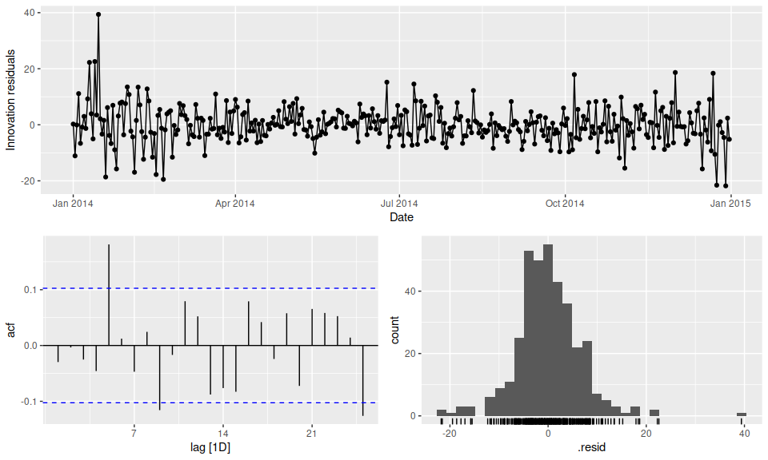

El modelo dista de ser perfecto. Hay autocorrelación en los residuos, el histograma muestra que los residuos tienen colas pesadas, y el test de Ljung-Box muestra que los residuos están lejos de ser ruido blanco.

No obstante, el texto dice que los point forecasts deberían ser razonables (no así los intervalos de confianza).

Para poder forecastear, debemos crear un nuevo dataset con las variables predictoras. En este caso usa un escenario en el que fija la temperatura para los próximos 14 días en 26 grados, sin feriados a partir del 1 de enero:

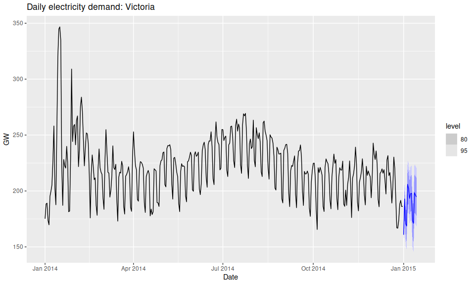

```r
vic_elec_future <- new_data(vic_elec_daily, 14) |>
  mutate(
    Temperature = 26,
    Holiday = c(TRUE, rep(FALSE, 13)),
    Day_Type = case_when(
      Holiday ~ "Holiday",
      wday(Date) %in% 2:6 ~ "Weekday",
      TRUE ~ "Weekend"
    )
  )
forecast(fit, vic_elec_future) |>
  autoplot(vic_elec_daily) +
  labs(
    title = "Daily electricity demand: Victoria",
    y = "GW"
  )
```

## Dymamic Harmonic regression

Cuando los períodos son demasiado largos, los modelos ARIMA y ETS no pueden manejarlos bien. ETS se banca hasta longitud 24 (períodos de 24 horas), y ARIMA hasta 350, aunque tener problemas de memoria para más de 200.

En esos casos es mejor usar modelos de regresión dinámica con dejando que la estacionalidad sea manejada por términos de Fourier, y los errores por un modelo ARIMA sin estacionalidad.

### Example: Australian eating out expenditure

Usamos los datos de gasto en comer afuera en Australia. Como los agrupamos a nivel mensual, la estacionalidad es de 12 meses y podríamos usar tanto un modelo ARIMA como ETS. Pero para ejemplificar el uso de Fourier, usamos un modelo de regresión dinámica, viendo ya que estamos cómo andaría para modelos ARIMA y ETS puros.

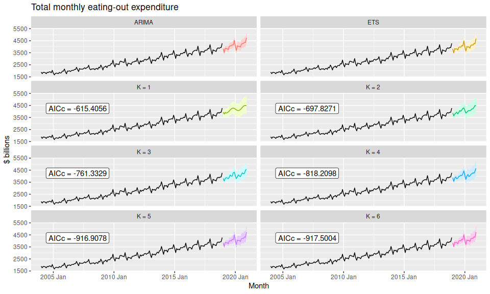

```r
aus_cafe <- aus_retail |>
  filter(
    Industry == "Cafes, restaurants and takeaway food services",
    year(Month) %in% 2004:2018
  ) |>
  summarise(Turnover = sum(Turnover))

fit <- model(aus_cafe,
  `ARIMA` = ARIMA(log(Turnover)),
  `ETS` = ETS(log(Turnover)),
  `K = 1` = ARIMA(log(Turnover) ~ fourier(K=1) + PDQ(0,0,0)),
  `K = 2` = ARIMA(log(Turnover) ~ fourier(K=2) + PDQ(0,0,0)),
  `K = 3` = ARIMA(log(Turnover) ~ fourier(K=3) + PDQ(0,0,0)),
  `K = 4` = ARIMA(log(Turnover) ~ fourier(K=4) + PDQ(0,0,0)),
  `K = 5` = ARIMA(log(Turnover) ~ fourier(K=5) + PDQ(0,0,0)),
  `K = 6` = ARIMA(log(Turnover) ~ fourier(K=6) + PDQ(0,0,0))
)

fit |>
  forecast(h = "2 years") |>
  autoplot(aus_cafe, level = 95) +
  facet_wrap(vars(.model), ncol = 2) +
  guides(colour = "none", fill = "none", level = "none") +
  geom_label(
    aes(x = yearmonth("2007 Jan"), y = 4250,
        label = paste0("AICc = ", format(AICc))),
    data = glance(fit) %>% filter(.model %>% startsWith("K = "))
  ) +
  labs(title= "Total monthly eating-out expenditure",
       y="$ billions")
```

Modelos elejidos encada caso:

```r
fit %>% pivot_longer(1:8)
```

```
## # A mable: 8 x 2
## # Key:     name [8]
##   name                               value
##   <chr>                            <model>
## 1 ARIMA <ARIMA(1,0,1)(2,1,0)[12] w/ drift>
## 2 ETS                         <ETS(M,A,M)>
## 3 K = 1        <LM w/ ARIMA(2,1,3) errors>
## 4 K = 2        <LM w/ ARIMA(5,1,1) errors>
## 5 K = 3        <LM w/ ARIMA(3,1,1) errors>
## 6 K = 4        <LM w/ ARIMA(1,1,5) errors>
## 7 K = 5        <LM w/ ARIMA(2,1,0) errors>
## 8 K = 6        <LM w/ ARIMA(0,1,1) errors>
```